# Assignment_1_CAP3330_Fall26

### **Question 2** (30 points)

A health psychologist wants to assess whether people living in rural areas have lower average life satisfaction scores than people living in urban areas. She collected life satisfaction scores for two random samples of residents, one from rural areas and one from urban areas. Each resident was given a score between 0 and 100 (higher scores mean more life satisfaction).

Assume that the variables involved in this problem follow a normal distribution.

The scores she collected are shown next. Create two vectors in R with these data.

Rural scores: 82 60 65 69 57 65 65 47 75 71 59 63 70 62 63 50 71 66 68 50 82 67 61 85 65 50 61 42 75 61

Urban scores: 68 86 58 80 54 68 63 90 93 72 83 73 81 67 58 57 79 97 78 70 94 77 76 78 74 72 61 80 74 87

create these two vectors

```r
rural <- c(
  82, 60, 65, 69, 57, 65, 65, 47, 75, 71,
  59, 63, 70, 62, 63, 50, 71, 66, 68, 50,
  82, 67, 61, 85, 65, 50, 61, 42, 75, 61
)

urban <- c(
  68, 86, 58, 80, 54, 68, 63, 90, 93, 72,
  83, 73, 81, 67, 58, 57, 79, 97, 78, 70,
  94, 77, 76, 78, 74, 72, 61, 80, 74, 87
)
```

**a) (20 points) Run the relevant statistical test that will allow the psychologist to conduct the desired comparison. Make sure to do the following as you conduct the test:**

**- Set up the corresponding hypotheses.**

**- Make a decision and conclude using a significance level of 0.05. Justify your decision.**

**NOTE: You are NOT required to do an exploratory analysis before running the test.**

Hypotheses:

Version 1:

- Ho: μRural ≥ μUrban
- Ha: μRural < μUrban

Version 2:

Ho: The mean life satisfaction score of rural residents is greater than or equal to the mean life satisfaction score of urban residents.

Ha: The mean life satisfaction score of rural residents is lower than the mean life satisfaction score of urban residents.

Run the Corresponding Statistical Test

A var.test() is not necessary because the comparison of interest involves the population means, not the population variances. The Welch Two Sample t-test used by t.test() does not require the assumption of equal variances and can therefore be applied directly.

```r
t.test(rural, urban,
       alternative = "less")
```

```
##
##  Welch Two Sample t-test
##
## data:  rural and urban
## t = -3.8422, df = 57.317, p-value = 0.0001538
## alternative hypothesis: true difference in means is less than 0
## 95 percent confidence interval:
##       -Inf -6.044061
## sample estimates:
## mean of x mean of y
##  64.23333  74.93333
```

Decision

The p-value (0.0001538) is less than the significance level α = 0.05; therefore, we reject Ho and support Ha.

Conclusion

The data provide sufficient evidence to conclude that the average life satisfaction scores of people living in rural areas are lower than the average life satisfaction scores of people living in urban areas.

Justification

Since the p-value (0.0001538) is less than α = 0.05, the observed difference between the sample means is statistically significant and is unlikely to have occurred due to random sampling variation alone. Therefore, the data support the psychologist’s claim that rural residents have lower average life satisfaction than urban residents.

**b) (10 points) THIS IS A CHALLENGE QUESTION**

**Challenge questions are those with somewhat low weight but where you cannot ask me any questions about how to answer them.**

**To evaluate the practical significance of the test results, the psychologist applies the following ad-hoc criterion established in the psychological well-being literature: a statistically significant difference between the means is considered practically significant (i.e., large enough to have real-life consequences) only if the absolute difference between the sample means is at least half the pooled standard deviation. Evaluate the practical significance of the test results using this ad-hoc criterion.**

Practical Significance Assessment

The psychologist’s criterion states that a statistically significant difference is considered practically significant only if the absolute difference between the sample means is at least half the pooled standard deviation.

Compute the Pooled Standard Deviation

```r
sp_life <- sqrt(
  (29 * var(rural) + 29 * var(urban)) /
  (30 + 30 - 2)
)
round(sp_life, 2)
```

```
## [1] 10.79
```

Compute the Absolute Difference Between the Sample Means

```r
mean_diff <- abs(mean(rural) - mean(urban))
round(mean_diff, 2)
```

```
## [1] 10.7
```

Compute Half the Pooled Standard Deviation

```r
round(sp_life / 2, 2)
```

```
## [1] 5.39
```

Assessment of Practical Significance

The pooled standard deviation is 10.79. According to the criterion provided, a difference is considered practically significant if the absolute difference between the sample means is at least half the pooled standard deviation.

Half the pooled standard deviation is: *5.39*

The absolute difference between the sample means is: *10.70*

Since

> 10.70 > 5.39

the observed difference exceeds the criterion for practical significance.

Conclusion

The difference in life satisfaction scores between rural and urban residents is practically significant according to the criterion provided. The absolute difference between the sample means (10.70) is greater than half the pooled standard deviation (5.39).

Therefore, the difference is large enough to be considered meaningful in practical terms and may have real-life consequences.

Furthermore, because the hypothesis test was statistically significant (p-value = 0.0001538 < 0.05), the results indicate that the difference is both statistically significant and practically significant.

**Additional Visualization (Not Required):**

**The following graph was created only to visually illustrate the decision of the hypothesis test and is not part of the required statistical analysis.**

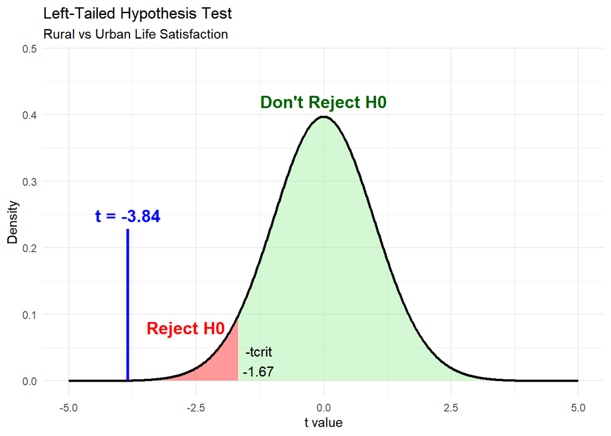

Critical value

```
## [1] -1.67
```

The critical value for a left-tailed test with α = 0.05 and 57.317 degrees of freedom is approximately -1.67.

Any t-statistic smaller than -1.67 falls in the rejection region.

Since the observed test statistic is **t = -3.84, and -3.84 < -1.67**,

the test statistic falls within the rejection region. Therefore, the null hypothesis is rejected.

The red region represents the rejection region for *α = 0.05*. The green region represents the non-rejection region. The observed test statistic *(t = -3.8422)* falls inside the rejection region because it is smaller than the critical value. Therefore, the null hypothesis is rejected. This provides statistical evidence that the average life satisfaction score of rural residents is lower than that of urban residents.

### **Question 3** (30 points)

**A medical researcher conjectures that the likelihood of having wrinkled skin around the eyes increases when a person smokes. The smoking habits as well as the presence of prominent wrinkles around the eyes were recorded for 500 randomly selected people from the population of interest. The following frequency table is obtained:**

|  | Prominent Wrinkles | Wrinkles not prominent |
| --- | --- | --- |
| **Heavy smoker** | 95 | 55 |
| **Light smoker** | 75 | 75 |
| **Non-smoker** | 66 | 134 |

Create the matrix of counts

```r
matrix_smoking_wrinkles <- matrix(
  c(95, 55,
    75, 75,
    66, 134),
  nrow = 3,
  byrow = TRUE,
  dimnames = list(
    c("Heavy smoker", "Light smoker", "Non-smoker"),
    c("Prominent Wrinkles", "Wrinkles not prominent")
  )
)

matrix_smoking_wrinkles
```

```
##              Prominent Wrinkles Wrinkles not prominent
## Heavy smoker                 95                     55
## Light smoker                 75                     75
## Non-smoker                   66                    134
```

**a) (20 points) Conduct the relevant statistical test to find out if someone’s smoking habits are associated with the presence of skin wrinkles. Use alpha= 0.05. You must follow these steps to conduct this test:**

- **a1) State the hypotheses (Ho and Ha).**
- **a2) Whether you reject or fail to reject Ho and why.**
- **a3) Your conclusion (i.e., whether smoking is associated with having wrinkles).**

**a1) State the hypotheses (Ho and Ha).**

- Ho: Smoking habits and the presence of prominent wrinkles around the eyes are independent (wrinkles are not associated with smoking habits).
- Ha: Smoking habits and the presence of prominent wrinkles around the eyes are dependent (wrinkles are associated with smoking habits).

Exploratory Analysis

Compute the conditional probabilities of wrinkle status given smoking category:

```r
round(prop.table(matrix_smoking_wrinkles, margin = 1) * 100, 2)
```

```
##              Prominent Wrinkles Wrinkles not prominent
## Heavy smoker              63.33                  36.67
## Light smoker              50.00                  50.00
## Non-smoker                33.00                  67.00
```

Conclusion from the Exploratory Analysis

Among heavy smokers, approximately 63.33% have prominent wrinkles around the eyes. Among light smokers, 50.00% have prominent wrinkles around the eyes, whereas among non-smokers only 33.00% have prominent wrinkles around the eyes.

Therefore, it appears that smoking habits may be associated with the presence of prominent wrinkles around the eyes. In particular, the proportion of individuals with prominent wrinkles seems to increase as smoking intensity increases.

However, we cannot rule out that the observed differences are simply due to sampling variability. Therefore, we will conduct a chi-square test of independence to assess the statistical significance of the observed relationship.

STATISTICAL ASSESSMENT ANALYSIS

Run the Chi-Square Test of Independence

Because both variables (smoking habits and wrinkle status) are categorical and the goal is to determine whether they are associated, a Chi-Square Test of Independence is the appropriate statistical procedure.

```r
chisq.test(matrix_smoking_wrinkles)
```

```
##
##  Pearson's Chi-squared test
##
## data:  matrix_smoking_wrinkles
## X-squared = 32.32, df = 2, p-value = 9.59e-08
```

**a2) Whether you reject or fail to reject Ho and why.**

Decision

The p-value (9.59 × 10⁻⁸) is less than the significance level α = 0.05; therefore, we reject Ho and support Ha.

**a3) Your conclusion (i.e., whether smoking is associated with having wrinkles).**

Conclusion

The data provide sufficient evidence to conclude that smoking habits and the presence of prominent wrinkles around the eyes are associated. Therefore, the results support the researcher’s conjecture that smoking is associated with having wrinkles around the eyes.

Validity Condition

Validity condition: All expected counts are greater than or equal to 5.

```r
chisq.test(matrix_smoking_wrinkles)$expected
```

```
##              Prominent Wrinkles Wrinkles not prominent
## Heavy smoker               70.8                   79.2
## Light smoker               70.8                   79.2
## Non-smoker                 94.4                  105.6
```

All expected counts are above 5; therefore, the validity condition for the chi-square test is satisfied.

**b) (10 points) Conduct a deeper analysis to know which smoking category is associated with prominent wrinkles, and which one is linked to non-prominent wrinkles. Show your work and discuss your results.**

Deeper Analysis

Because we rejected Ho, we can ask: which smoking categories are associated with prominent wrinkles and which are associated with non-prominent wrinkles?

Pearson residuals contain that information.

```r
round(chisq.test(matrix_smoking_wrinkles)$residuals,2)
```

```
##              Prominent Wrinkles Wrinkles not prominent
## Heavy smoker               2.88                  -2.72
## Light smoker               0.50                  -0.47
## Non-smoker                -2.92                   2.76
```

Discussion of Results:

- The combination Heavy Smoker and Prominent Wrinkles has a large positive residual (2.88). Therefore, heavy smokers have prominent wrinkles more often than expected under independence.
- The combination Heavy Smoker and Wrinkles Not Prominent has a negative residual (-2.72). Therefore, heavy smokers are less likely to belong to the non-prominent wrinkles category.
- The combination Non-Smoker and Prominent Wrinkles has a large negative residual (-2.92). Therefore, non-smokers have prominent wrinkles less often than expected under independence.
- The combination Non-Smoker and Wrinkles Not Prominent has a large positive residual (2.76). Therefore, non-smokers are more likely to belong to the non-prominent wrinkles category.
- The residuals for light smokers are close to zero, suggesting little deviation from what would be expected under independence.

Final Conclusion:

Heavy smokers are associated with prominent wrinkles around the eyes, while non-smokers are associated with non-prominent wrinkles around the eyes. Light smokers do not show a strong association with either wrinkle category. These findings reinforce the conclusion of the chi-square test and provide additional evidence supporting the researcher’s conjecture that the likelihood of having wrinkles around the eyes increases with smoking.

**Additional Visualization (Not Required):**

**The following graph was created only to visually illustrate the decision of the hypothesis test and is not part of the required statistical analysis.**

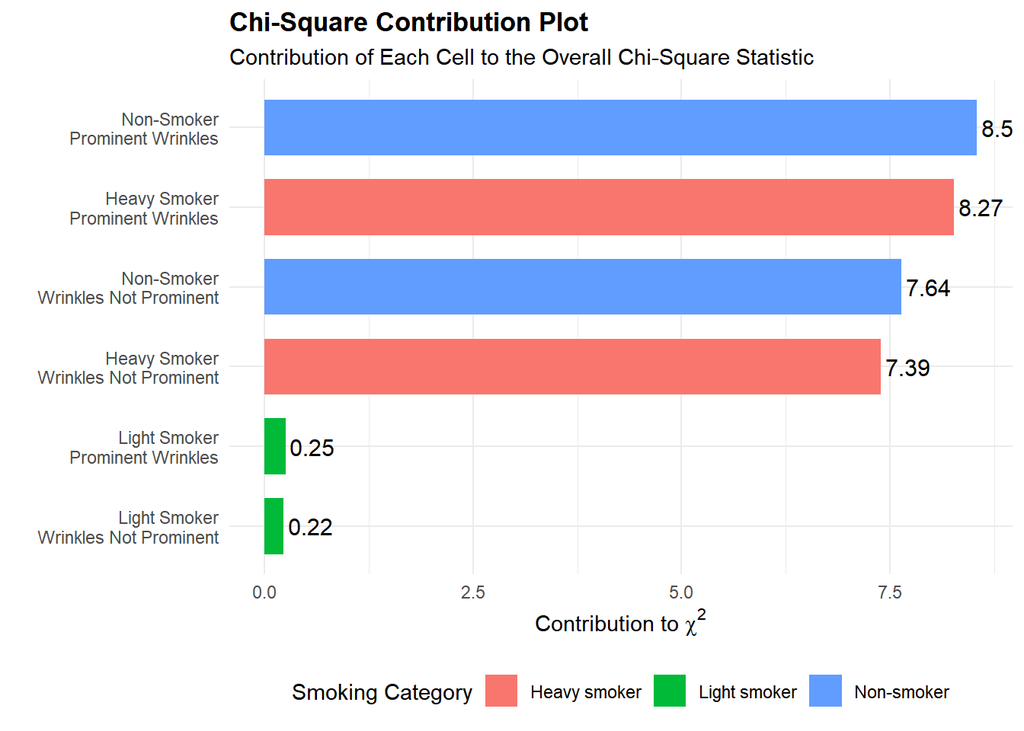

The graph shows the contribution of each cell to the overall Chi-Square statistic. Cells with larger contributions are those that differ the most from the values expected under independence.

The largest contributions come from the combinations Heavy Smoker + Prominent Wrinkles, Heavy Smoker + Wrinkles Not Prominent, Non-Smoker + Prominent Wrinkles, and Non-Smoker + Wrinkles Not Prominent. These combinations are primarily responsible for the rejection of the null hypothesis.

In contrast, the contributions associated with light smokers are very small, indicating that their observed counts are close to what would be expected if smoking habits and wrinkle status were independent.

Therefore, the graph supports the conclusion that heavy smokers are associated with prominent wrinkles, whereas non-smokers are associated with non-prominent wrinkles.